# Group assignment - part 1

# Initial Exploration

## Inspecting Data Structure and Descriptives

To verify the data was loaded in correctly, the first and last 10 rows are displayed for an overview of the content.

Additionally, we compute basic data descriptives to quickly inspect the distribution of each variable.

```r
data %>%
  rename(c(Dance = Danceability, Loud = Loudness, Live = Liveness, Acoustic = Acousticness, Speech = Speechiness, Popular = Popularity)) %>%
  head(10) %>%
  kable() %>%
  kable_styling("striped", full_width = F)
```

| ID | Title | Artist | Genre | Year | BPM | Energy | Dance | Loud | Live | Valence | Duration | Acoustic | Speech | Popular |
| --- | --- | --- | --- | --- | --- | --- | --- | --- | --- | --- | --- | --- | --- | --- |
| 1 | Sunrise | Norah Jones | adult standards | 2004 | 157 | 30 | 53 | -14 | 11 | 68 | 201 | 94 | 3 | 71 |
| 2 | Black Night | Deep Purple | album rock | 2000 | 135 | 79 | 50 | -11 | 17 | 81 | 207 | 17 | 7 | 39 |
| 3 | Clint Eastwood | Gorillaz | alternative hip hop | 2001 | 168 | 69 | 66 | -9 | 7 | 52 | 341 | 2 | 17 | 69 |
| 4 | The Pretender | Foo Fighters | alternative metal | 2007 | 173 | 96 | 43 | -4 | 3 | 37 | 269 | 0 | 4 | 76 |
| 5 | Waitin’ On A Sunny Day | Bruce Springsteen | classic rock | 2002 | 106 | 82 | 58 | -5 | 10 | 87 | 256 | 1 | 3 | 59 |
| 6 | The Road Ahead (Miles Of The Unknown) | City To City | alternative pop rock | 2004 | 99 | 46 | 54 | -9 | 14 | 14 | 247 | 0 | 2 | 45 |
| 7 | She Will Be Loved | Maroon 5 | pop | 2002 | 102 | 71 | 71 | -6 | 13 | 54 | 257 | 6 | 3 | 74 |
| 8 | Knights of Cydonia | Muse | modern rock | 2006 | 137 | 96 | 37 | -5 | 12 | 21 | 366 | 0 | 14 | 69 |
| 9 | Mr. Brightside | The Killers | modern rock | 2004 | 148 | 92 | 36 | -4 | 10 | 23 | 223 | 0 | 8 | 77 |
| 10 | Without Me | Eminem | detroit hip hop | 2002 | 112 | 67 | 91 | -3 | 24 | 66 | 290 | 0 | 7 | 82 |

```r
data %>%
  rename(c(Dance = Danceability, Loud = Loudness, Live = Liveness, Acoustic = Acousticness, Speech = Speechiness, Popular = Popularity)) %>%
  tail(10) %>%
  kable() %>%
  kable_styling("striped", full_width = F)
```

|  | ID | Title | Artist | Genre | Year | BPM | Energy | Dance | Loud | Live | Valence | Duration | Acoustic | Speech | Popular |
| --- | --- | --- | --- | --- | --- | --- | --- | --- | --- | --- | --- | --- | --- | --- | --- |
| 1985 | 1985 | Suite: Judy Blue Eyes - Remastered | Crosby, Stills & Nash | album rock | 1969 | 154 | 36 | 45 | -13 | 20 | 30 | 444 | 47 | 4 | 67 |
| 1986 | 1986 | Blue Suede Shoes | Elvis Presley | adult standards | 1956 | 95 | 66 | 56 | -8 | 14 | 96 | 119 | 65 | 6 | 62 |
| 1987 | 1987 | Jailhouse Rock | Elvis Presley | adult standards | 1958 | 167 | 58 | 65 | -10 | 7 | 92 | 146 | 41 | 8 | 73 |
| 1988 | 1988 | My Baby Just Cares for Me - 2013 Remastered Version | Nina Simone | adult standards | 1958 | 119 | 24 | 75 | -15 | 9 | 43 | 216 | 83 | 12 | 68 |
| 1989 | 1989 | Summertime | Louis Armstrong | adult standards | 1958 | 168 | 7 | 17 | -21 | 14 | 10 | 298 | 92 | 3 | 66 |
| 1990 | 1990 | Heartbreak Hotel | Elvis Presley | adult standards | 1958 | 94 | 21 | 70 | -12 | 11 | 72 | 128 | 84 | 7 | 63 |
| 1991 | 1991 | Hound Dog | Elvis Presley | adult standards | 1958 | 175 | 76 | 36 | -8 | 76 | 95 | 136 | 73 | 6 | 69 |
| 1992 | 1992 | Johnny B. Goode | Chuck Berry | blues rock | 1959 | 168 | 80 | 53 | -9 | 31 | 97 | 162 | 74 | 7 | 74 |
| 1993 | 1993 | Take Five | The Dave Brubeck Quartet | bebop | 1959 | 174 | 26 | 45 | -13 | 7 | 60 | 324 | 54 | 4 | 65 |
| 1994 | 1994 | Blueberry Hill | Fats Domino | adult standards | 1959 | 133 | 50 | 49 | -10 | 16 | 83 | 148 | 74 | 3 | 56 |

```r
psych::describe(data[5:ncol(data)]) %>%
  dplyr::select(mean, sd, median, min, max, skew, kurtosis) %>%
  round(3) %>%
  kable() %>%
  kable_styling("striped", full_width = F)
```

|  | mean | sd | median | min | max | skew | kurtosis |
| --- | --- | --- | --- | --- | --- | --- | --- |
| Year | 1992.993 | 16.116 | 1993 | 1956 | 2019 | -0.121 | -1.192 |
| BPM | 120.216 | 28.028 | 119 | 37 | 206 | 0.418 | -0.154 |
| Energy | 59.680 | 22.154 | 61 | 3 | 100 | -0.248 | -0.836 |
| Danceability | 53.238 | 15.352 | 53 | 10 | 96 | 0.015 | -0.348 |
| Loudness | -9.009 | 3.648 | -8 | -27 | -2 | -0.823 | 0.786 |
| Liveness | 19.012 | 16.727 | 12 | 2 | 99 | 2.373 | 6.181 |
| Valence | 49.409 | 24.858 | 47 | 3 | 99 | 0.202 | -1.047 |
| Duration | 262.443 | 93.604 | 245 | 93 | 1412 | 4.197 | 36.063 |
| Acousticness | 28.858 | 29.012 | 18 | 0 | 99 | 0.796 | -0.672 |
| Speechiness | 4.995 | 4.402 | 4 | 2 | 55 | 4.892 | 31.753 |
| Popularity | 59.527 | 14.352 | 62 | 11 | 100 | -0.533 | -0.122 |

## Plots

### Plot 1 - Correlation Matrix

We create a correlation “heatmap” to visualize relationships among all numeric variables. The heatmap uses a color gradient to show the strength of the correlations.

It helps us identify which audio features are strongly correlated with popularity and also whether multicollinearity may impact final model predictions.

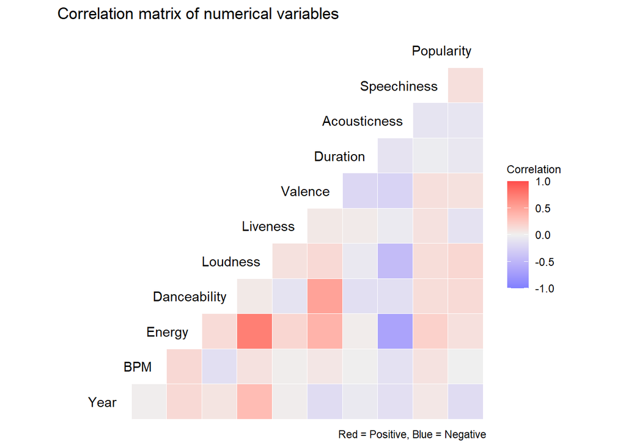

```r
# Plotting heatmap using ggcorr, storing in object
corplot <- ggcorr(
  data[5:ncol(data)],
  label = F,
  layout.exp = 1,
  low = "#7F7FFF",          # blue for negative
  mid = "#EFEFEF",
  high = "#FF4C4C",         # red for positive
  name = "Correlation"
  ) +
  labs(
    title = "Correlation matrix of numerical variables",
    caption = "Red = Positive, Blue = Negative"
    )

# Adjusting labels to prevent overlap
corplot$layers[[2]]$aes_params$hjust <- 0.9

# Display plot
corplot
```

### Interpretation of Plot 1

It appears that Year and Liveness have a slight negative correlation with popularity. This means that modern tracks and live recordings are less favored.

Loudness, Danceability, Energy, Speechiness and Valence have a slight positive correlation with popularity. Loud, happy, high-energy dance tracks with vocals do seem like a good recipe for a hit at face value.

### Plot 2 - Feature Average by Release Year

We calculate the average values of Danceability, Energy, Loudness, and Popularity by release year. A line plot is used to visualize the trends and it allows us to explore how these features vary with tracks of different ages, comparing classics with modern tracks.

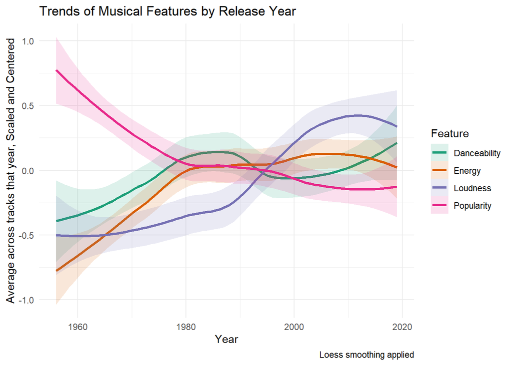

```r
data_plot_1 <- data[5:ncol(data)] %>%
  mutate(across(c("Danceability", "Loudness", "Energy", "Popularity"),
                ~ as.vector(scale(.x, center = T, scale = T)))) %>%
  pivot_longer(cols = c(Danceability, Loudness, Energy, Popularity),
               names_to = "Feature",
               values_to = "Value") %>%
  group_by(Year, Feature) %>%
  summarise(Avg_Value = mean(Value, na.rm = TRUE), .groups = "drop")


ggplot(data_plot_1, aes(x = Year, y = Avg_Value, color = Feature, fill = Feature)) +
  geom_smooth(linewidth = 1.2, alpha = 0.15, ) +
  scale_color_brewer(palette="Dark2", aesthetics = c("colour", "fill")) +
  labs(title = "Trends of Musical Features by Release Year",
       x = "Year",
       y = "Average across tracks that year, Scaled and Centered",
       caption = "Loess smoothing applied") +
  theme_minimal()
```

### Interpretation of Plot 2

Popularity is trending down with Release Year, aligning with our observations from the correlation matrix. Especially tracks from before the 1980’s appear to be popular despite their low Danceability, Energy and Loudness ratings.

Danceability, Energy and Loudness appear to have become more prevalent over time.

The confidence interval for these trends is quite wide, there is a lot of variance in these values from year to year, so these trends should be taken with some scrutiny.

### Plot 3 - Feature Average by Popularity Rating

Similar to Plot 2, we calculate the average values of Danceability, Energy and Loudness, but this time by Popularity rating. This will allows us to explore what Features tend to have high values in the least and most popular tracks.

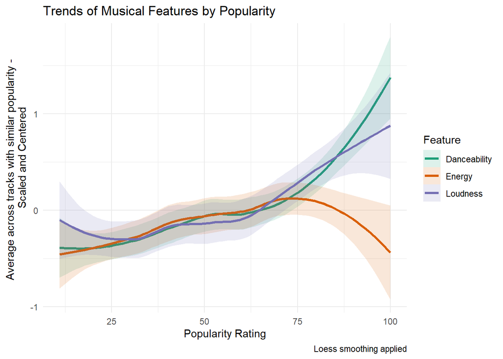

```r
data_plot_2 <- data[5:ncol(data)] %>%
  mutate(across(c("Danceability", "Loudness", "Energy"),
                ~ as.vector(scale(.x, center = T, scale = T)))) %>%
  pivot_longer(cols = c(Danceability, Loudness, Energy),
               names_to = "Feature",
               values_to = "Value") %>%
  group_by(Popularity, Feature) %>%
  summarise(Avg_Value = mean(Value, na.rm = TRUE), .groups = "drop")


ggplot(data_plot_2, aes(x = Popularity, y = Avg_Value, color = Feature, fill = Feature)) +
  geom_smooth(linewidth = 1.2, alpha = 0.15, ) +
  scale_color_brewer(palette="Dark2", aesthetics = c("colour", "fill")) +
  labs(title = "Trends of Musical Features by Popularity",
       x = "Popularity Rating",
       y = "Average across tracks with similar popularity -
       Scaled and Centered",
       caption = "Loess smoothing applied") +
  theme_minimal()
```

### Interpretation of Plot 3

There is a lot of overlap in the 25-75 range of Popularity Rating. There is a clear upwards trend for these Features, though Energy appears to trend down in the most higly rated tracks.

# Research question and Hypothesis

Based on our data exploration, we formulate the following research question: Which audio features best predict a song’s popularity on Spotify?

We predict that Danceability and Loudness will be among the most important features for predicting Popularity.

# Modelling the data

## Data partitioning

We split the dataset into training (70%), validation (15%), and test (15%) sets. We then plot the density of popularity scores across all sets within a single plot to ensure similar distributions. The data partitioning prepares the data for model training and evaluation, while the density plot confirms that the splits are balanced to ensure that model performance metrics are reliable.

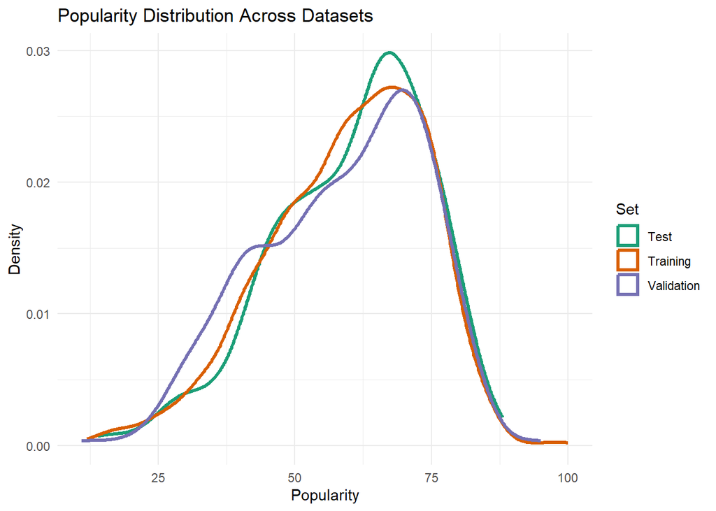

```r
# 70% train, 15% validation, 15% test
n <- nrow(data)
train_index <- sample(1:n, size = 0.7 * n)
remaining <- setdiff(1:n, train_index)
valid_index <- sample(remaining, size = 0.5 * length(remaining))
test_index <- setdiff(remaining, valid_index)

data_train <- data[train_index, ]
data_valid <- data[valid_index, ]
data_test  <- data[test_index, ]


# Combine the datasets, adding a column to distinguish them
combined_data <- bind_rows(
  mutate(data_train, Set = "Training"),
  mutate(data_valid, Set = "Validation"),
  mutate(data_test, Set = "Test")
)

# Checking if the distribution of popularity is similar in the three datasets
ggplot(combined_data, aes(x = Popularity, colour = Set)) +
  geom_density(trim = T, linewidth = 1.2) +
  scale_color_brewer(palette="Dark2") +
  labs(title = "Popularity Distribution Across Datasets",
       x = "Popularity",
       y = "Density") +
  theme_minimal()
```

## Lasso-Regression

We perform Lasso regression to identify the most predictive feature for popularity.

It is ideal for our purpose, as it sets insignificant feature coefficients to zero, resulting in a model that showcases the most predictive features.

The matrices are prepared by excluding any non-numeric columns and cross-validation then finds the optimal lambda to use for fitting the final model.

We have this model make predictions on the validation set and compute the mean squared error to evaluate its performance.

```r
# Prepare model matrices
x <- model.matrix(Popularity ~ . - ID - Title - Artist - Genre, data_train)[, -1]
y <- data_train$Popularity

x_valid <- model.matrix(Popularity ~ . - ID - Title - Artist - Genre, data_valid)[, -1]
y_valid <- data_valid$Popularity

# Lasso Regression with cross-validation
cv_lasso <- cv.glmnet(x, y, alpha = 1)
best_lambda <- cv_lasso$lambda.min

# Fit final model
lasso_model <- glmnet(x, y, alpha = 1, lambda = best_lambda)

# Predict on validation data
pred_valid <- predict(lasso_model, s = best_lambda, newx = x_valid)

# Compute validation MSE
lasso_mse <- mean((y_valid - pred_valid)^2)
lasso_mse
```

```
## [1] 190.3047
```

```r
# Extract coefficients from Lasso model
lasso_coef <- coef(lasso_model)

# Convert to data frame
lasso_coef_df <- as.data.frame(as.matrix(lasso_coef))
colnames(lasso_coef_df) <- "Coefficient"

# feature names
lasso_coef_df <- lasso_coef_df %>%
  rownames_to_column(var = "Feature") %>%
  filter(Coefficient != 0) %>%
  arrange(desc(abs(Coefficient)))

# table
kable(lasso_coef_df, caption = "Significant Predictors") %>%
  kable_styling("striped", full_width = F) %>%
  scroll_box(width = "600px", height = "400px")
```

Significant Predictors

| Feature | Coefficient |
| --- | --- |
| (Intercept) | 572.7183363 |
| Loudness | 1.3948782 |
| Speechiness | 0.4337664 |
| Year | -0.2500650 |
| Danceability | 0.1469407 |
| Energy | -0.1240635 |
| Liveness | -0.1057588 |
| Acousticness | -0.0346831 |
| Valence | -0.0305043 |
| BPM | 0.0114502 |
| Duration | -0.0066302 |

# Conclusion

In this analysis, we looked at which audio features help predict how popular a song is on Spotify. We used the Lasso regression to find out which characteristics matter most.

Loudness had the biggest positive effect, meaning louder songs tend to be more popular. Speechiness and danceability also had positive impacts, while features like energy and liveness had smaller negative effects.

Interestingly, the year had a negative relationship, which might suggest older songs are more popular in this dataset.

# Contribution

Osaro: Created Plot 1, wrote the Research question and conclusion. Wrote the lasso Regression.

Calvin: Created plot 2, Set up professional styling and report layout.

Mila: Added codebook and data descriptives. Refined plot 1 and plot 2, created plot 3 and provided interpretation. Created data partition density plot. Corrected some of the legitimization’s layout and structure.